# Exercise Day 7

Elisa

15 July 2019

# Exercise 1

### Plots

Load the data set “farms.txt”. In it, the plant size (“size”) of plants has been several times 5 times on each of 24 sites (“farms”). At the same spot the nitrogen concentration in the soil has been recorded (“N”). The question is, how plant size changes as nitrogen concentration changes. You analysed these data last week with a repeated measurements ANOVA.

```r
farms <- read.delim("data/farms.txt")
head(farms)
```

```
##          N     size farm
## 1 18.18014 96.48147    1
## 2 20.47343 98.64003    1
## 3 21.34757 99.36465    1
## 4 18.41299 93.19268    1
## 5 19.75629 98.39972    1
## 6 29.02022 99.53934    2
```

Try some plots to check how the data looks like using ggplot:

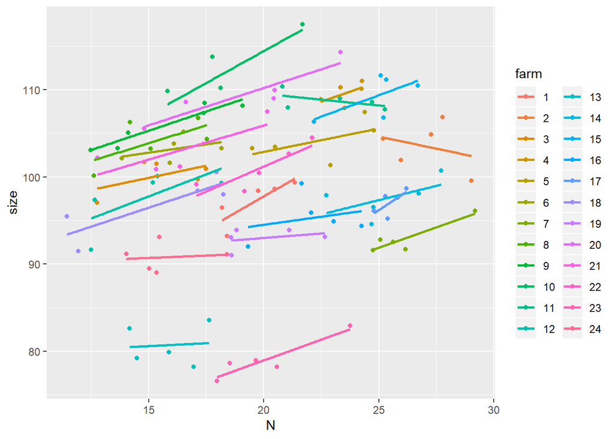

```r
library(tidyr)
library(dplyr)
library(ggplot2)
farms$farm <- as.factor(farms$farm)
farms %>% ggplot(aes(x=N, y=size, color=farm)) +
  geom_point()+
  geom_smooth(method = "lm", se=FALSE)
```

Some plots to check how the data looks like ussing lattice

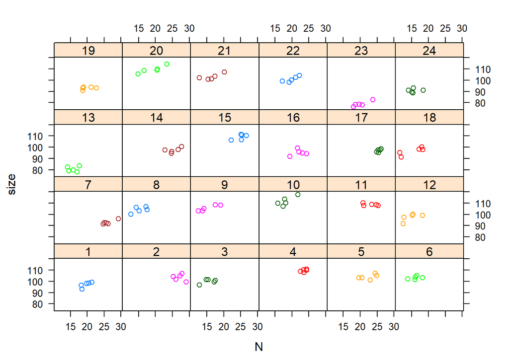

```r
library(lattice)
xyplot(size ~ N|farm, groups =farm, data=farms) # | adds facets, groups adds colors
```

More info on lattice (https://www.statmethods.net/advgraphs/trellis.html)

### Recipie for MEM

The recipe for implementing a Mixed Effects Model is

1. spot the grouping in the data

There is grouping for the farm factor

2. how many random effects are there in the data?

One RE for farm.

3. if two or more, are they nested? Can you spot that from the data labeling, or if not, is there any reason to suspect nesting / crossing?

There are not

4. define the deterministic part of the model, i.e. find the fixed effects incl. their interactions and potential quadratic / cubic etc. terms

Nitrogen can be a fixed effect if we are intrested on how the size changes with N

5. can you specify random slopes for one or all of the ranodm effects?

There can be a RS for N for each different farm.

### Fit with lme4

The following table shows how to specify different models

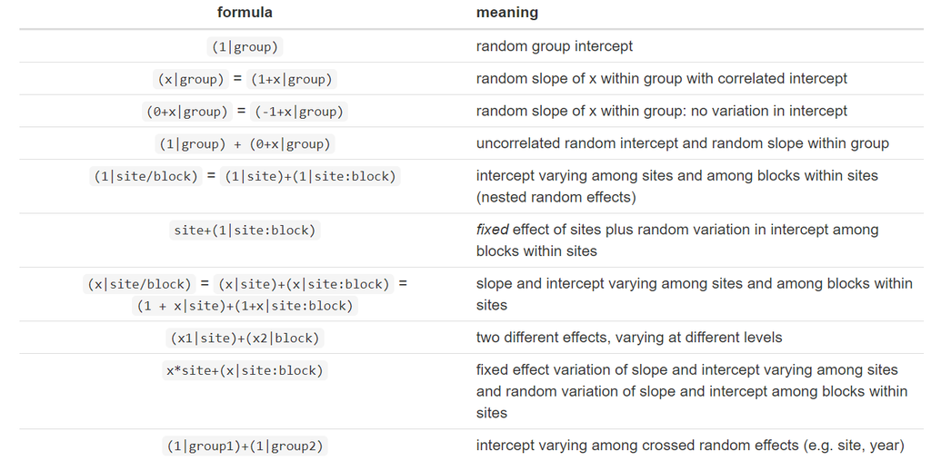

This table was taken from [GLMM FAQ from Bolker](https://bbolker.github.io/mixedmodels-misc/glmmFAQ.html#introduction)

```r
library(lme4)
lmer.1 <- lmer(size ~ N + (N|farm), data=farms)
```

LetÂ´s do some analysis to understand the model:

```r
summary (lmer.1)
```

```
## Linear mixed model fit by REML ['lmerMod']
## Formula: size ~ N + (N | farm)
##    Data: farms
##
## REML criterion at convergence: 605.8
##
## Scaled residuals:
##      Min       1Q   Median       3Q      Max
## -2.77041 -0.69280  0.04677  0.68458  2.18214
##
## Random effects:
##  Groups   Name        Variance  Std.Dev. Corr
##  farm     (Intercept) 49.501939 7.03576
##           N            0.005698 0.07548  1.00
##  Residual              3.695219 1.92230
## Number of obs: 120, groups:  farm, 24
##
## Fixed effects:
##             Estimate Std. Error t value
## (Intercept) 85.82439    2.31787  37.027
## N            0.69876    0.09301   7.513
##
## Correlation of Fixed Effects:
##   (Intr)
## N -0.668
```

In the **Random effects** section fo the summary we can see the variance components. The variance btw groups (intercept) and the variance within groups (residuals). N as random slope explains very little of variance. We can also see the correlation between the parameters.

In the **Scaled residuals** section we see the distribution of the residuals within grups. This should be more or less simetrical if its gaussian, which is the case.

In the **Fixed effects** we see the value of the parameters, intercept and slope. We also see the **Correlation of fixed effects** which is the correlation of the parameters.

The info from this [link from stack exchange](https://stats.stackexchange.com/questions/24452/how-to-interpret-variance-and-correlation-of-random-effects-in-a-mixed-effects-m) can hel to understand a bit more.

Owr summary shows something that should be at least distubing. The correlation between the intercept and random slope of the random effects have a correlation of one. This is not good and indicates that there are not enough data to estimate this correlation. There is not enough data to estimate the variation given by N iside each farm. This may occur because there is low variation of plant size for different N.

We should try to simplify owr model. There are two ways we can simplify it:

```r
# 1) remove this correlation:
lmer.2 <- lmer(size ~ N + (1|farm) + (0 + N|farm), farms)
# still singular fit! Check the variance term for the random slope: it is exactly zero, no variance left for the random effects part

# 2) remove the random intercept
lmer.3 <- lmer(size ~ N + (1|farm), farms)
```

### Fit with nlme

```r
library(nlme)

#Without random intercept
nlme.1 <- lme( size ~ N, random = ~ 1| farm, data = farms)

#With random intercept
#nlme.2 <- lme( size ~ N, random = ~ N| farm, data = farms)
#Gives an error, no convergence, related with the problem we found.

#Error in lme.formula(size ~ N, random = ~N | farm, data = farms) :
#nlminb problem, convergence error code = 1 message = iteration limit
#reached without convergence (10)
```

Lets see how the summary looks like:

```r
summary(nlme.1)
```

```
## Linear mixed-effects model fit by REML
##  Data: farms
##        AIC      BIC    logLik
##   614.3687 625.4515 -303.1844
##
## Random effects:
##  Formula: ~1 | farm
##         (Intercept) Residual
## StdDev:    8.506147 1.929859
##
## Fixed effects: size ~ N
##                Value Std.Error DF  t-value p-value
## (Intercept) 85.56750 2.5406539 95 33.67932       0
## N            0.70875 0.0928735 95  7.63133       0
##  Correlation:
##   (Intr)
## N -0.727
##
## Standardized Within-Group Residuals:
##         Min          Q1         Med          Q3         Max
## -2.79070207 -0.62807448  0.02781053  0.70358230  2.18211935
##
## Number of Observations: 120
## Number of Groups: 24
```

In the random effect we can see the variance components. The variance btw groups (intercept) and the variance within groups (residuals). The we see the distribution of the residuals within grups. Should be more or less simetrical if its gaussian, which is the case. Finally the tables give us info about AIC/BIC and about the estimations for the fixed effects.

**Random effects** The variance among groups is 8.51^2 = 72.35 (the standard deviation is the square root of the variance), while the the residual variance is 1.93 = 3.72. This means: most of the variance in plant size is thus due to random variation of farms around the population average 85.567. The intraclass correlation (ICC) is indeed 72.35 / (72.35 + 3.72) close to 1. Farms are quite similar within each other but quite different from each other.

**Fixed effects** Nitrogen concentration seems to affect plant growth rather little: with an increase by one unit, plant size rises by 0.708. This little variation with N may be the reason why random slope model does not converge: so much variance due to N is explained by N as a fixed effect, that a random slope is not supported.

To study the estiamtes of the variance components as Std and Variance we use varCorr

```r
VarCorr(nlme.1)
```

```
## farm = pdLogChol(1)
##             Variance  StdDev
## (Intercept) 72.354531 8.506147
## Residual     3.724354 1.929859
```

To see the estimates of the random predictors we use *ranef()

```r
ranef(nlme.1)
```

```
##    (Intercept)
## 1   -2.2443226
## 2   -1.2105507
## 3    3.5931384
## 4    7.2889436
## 5    2.6988830
## 6    6.1647689
## 7  -11.0413111
## 8    7.6340242
## 9    9.0800641
## 10  13.1661528
## 11   6.7775705
## 12   1.4896411
## 13 -15.9162496
## 14  -5.8928130
## 15   6.0022886
## 16  -5.8596949
## 17  -6.4927242
## 18   0.3306066
## 19  -6.6500412
## 20  10.2408742
## 21   5.8398184
## 22   1.3681441
## 23 -20.5532368
## 24  -5.8139744
```

We see here the estiated intercepts per farm, they are quite different from each other.

### Extra Exercise

Try and fit the model without the fixed effect but with N as random slope: what happens? Why? What can you say about the variances?

```r
nlme.2 <- lme(size ~ 1 , random = ~N|farm, data = farms )
summary(nlme.2)
```

```
## Linear mixed-effects model fit by REML
##  Data: farms
##        AIC      BIC    logLik
##   643.4823 657.3779 -316.7411
##
## Random effects:
##  Formula: ~N | farm
##  Structure: General positive-definite, Log-Cholesky parametrization
##             StdDev     Corr
## (Intercept) 12.3857435 (Intr)
## N            0.6215038 -0.735
## Residual     1.9826699
##
## Fixed effects: size ~ 1
##                Value Std.Error DF  t-value p-value
## (Intercept) 97.95196  1.810111 96 54.11378       0
##
## Standardized Within-Group Residuals:
##        Min         Q1        Med         Q3        Max
## -2.1936487 -0.5677702  0.0470189  0.6402203  2.0147621
##
## Number of Observations: 120
## Number of Groups: 24
```

The ammount of variance explained by N as random slope is even smaller that the residual variance. We can compare the two models. However we have to be carefull here. The two models differ in the fixed effects, so the fitting method should be ML.

```r
update(nlme.1, method = "ML")
```

```
## Linear mixed-effects model fit by maximum likelihood
##   Data: farms
##   Log-likelihood: -303.1885
##   Fixed: size ~ N
## (Intercept)           N
##  85.5812044   0.7080597
##
## Random effects:
##  Formula: ~1 | farm
##         (Intercept) Residual
## StdDev:    8.316789 1.920269
##
## Number of Observations: 120
## Number of Groups: 24
```

```r
update(nlme.2, method = "ML")
```

```
## Linear mixed-effects model fit by maximum likelihood
##   Data: farms
##   Log-likelihood: -318.2426
##   Fixed: size ~ 1
## (Intercept)
##    97.89836
##
## Random effects:
##  Formula: ~N | farm
##  Structure: General positive-definite, Log-Cholesky parametrization
##             StdDev     Corr
## (Intercept) 12.1531686 (Intr)
## N            0.6188543 -0.739
## Residual     1.9839397
##
## Number of Observations: 120
## Number of Groups: 24
```

```r
anova(nlme.1, nlme.2)
```

```
##        Model df      AIC      BIC    logLik   Test  L.Ratio p-value
## nlme.1     1  4 614.3687 625.4515 -303.1844
## nlme.2     2  5 643.4823 657.3779 -316.7411 1 vs 2 27.11355  <.0001
```

Then, the second model, no fixed effect and N as random slope, is worst than the first one. Yuhuu, this makes sense.

# Exercise 2

Load the data set “fertilizer”: it describes the height of plants grown from different seed categories over time:

- What would be the most complex random effects structutre you can imagine?
- Does the model fit?
- What is the simplest random effects structure you get running?

### Investigate and plot the data

```r
fertilizer <- read.delim("data/fertilizer.txt")
head(fertilizer)
```

```
##   root week plant fertilizer
## 1  1.3    2   ID1      added
## 2  3.5    4   ID1      added
## 3  7.0    6   ID1      added
## 4  8.1    8   ID1      added
## 5 10.0   10   ID1      added
## 6  2.0    2   ID2      added
```

We have root as a continious response variable. Plant and fertilizer are categorical. Week is continious accouting for time. Before doing anything else letÂ´s plot the data:

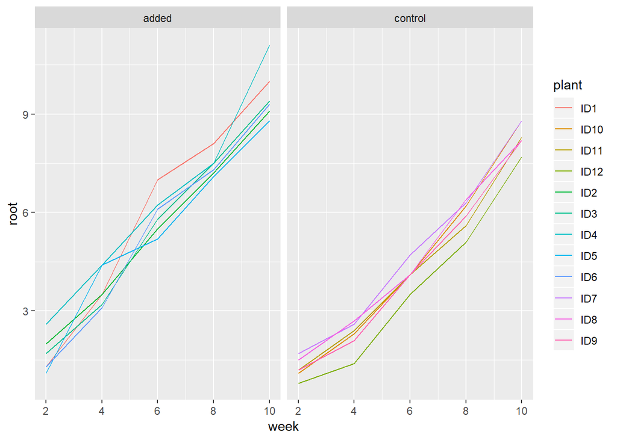

```r
fertilizer %>%ggplot(aes(y = root, x = week, color = plant)) +
  geom_line(aes(group = plant)) +
  facet_grid(~ fertilizer)
```

The same but with lattice (but I deffinitely prefer ggplot)

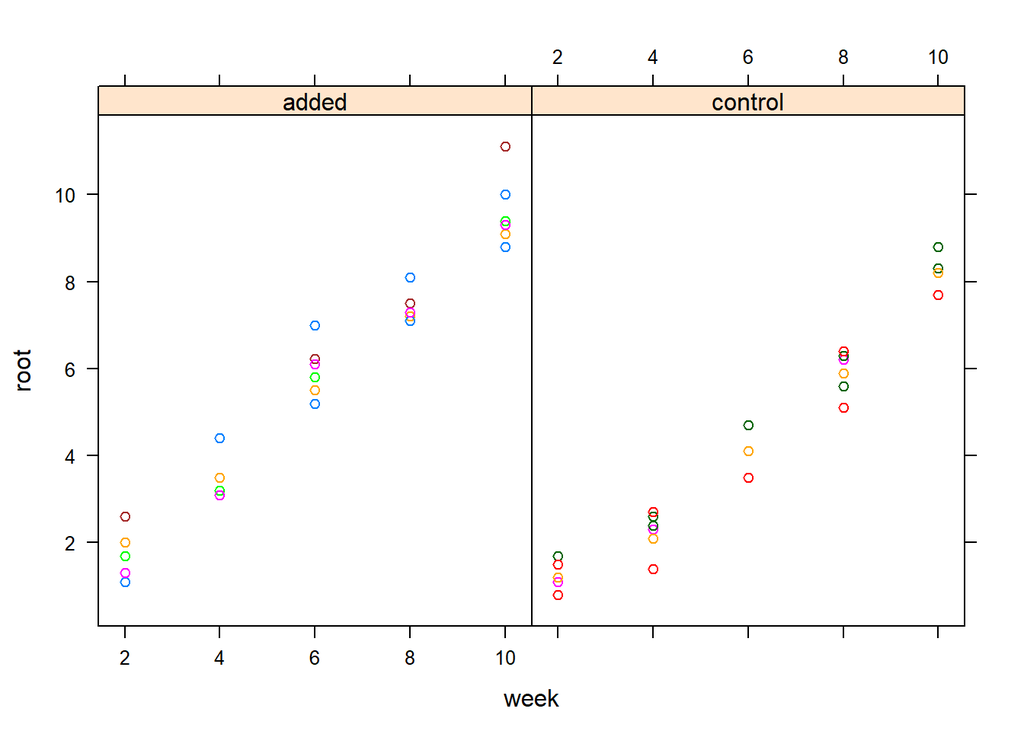

```r
xyplot(root~week|fertilizer, group=plant, fertilizer)
```

Wat do we see here?:

- A clear correlation for a given plant ID.
- We can some effect on fertilizer since the growth seems to be lower in non fertilized plants. Maybe plotting fertilized and non fertilized plants in the same graph shows a bit better this difference:

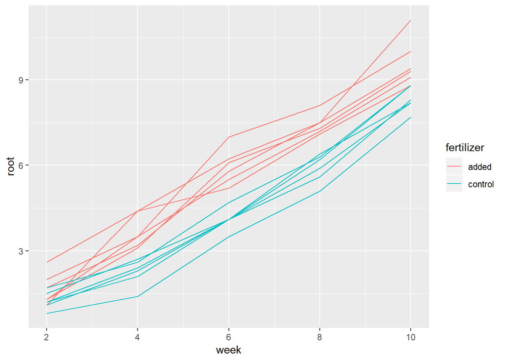

```r
fertilizer %>% ggplot(aes(y = root, x = week, color = fertilizer)) +
  geom_line(aes(group = plant))
```

With some more insights into the data we can try to follow the recipie

1. Spot the grouping in the data

There is a clear correlation for each plant. Plat ID is a grouping factor, all measures in the same plant are not independent.

2. how many random effects are there in the data?

Plant ID is deffinitely a random effect. We could allow a different slope for each plant ID. However, if we take a look at the plots, all the slope does not change much between plants. And we already know from the previous exercise that without too much data and adding random slopes might only conduce to a headache. However we culd try to incorporate the random slope into the model and then do model selection and let AIC to decide for us…

3. if two or more, are they nested? Can you spot that from the data labeling, or if not, is there any reason to suspect nesting / crossing?

Only one random effect so fat so…

4. define the deterministic part of the model, i.e. find the fixed effects incl. their interactions and potential quadratic / cubic etc. terms

Response is root, and the fixed factor is fertilizer. Time can also be a fixed effect on root.

5. can you specify random slopes for one or all of the ranodm effects?

We already discussed that on b.

### Fit for lme

Looking at the plots I am also not completely sure to incorporate an interactonn between the fixed effects. However, theoretically it is possible that this interaction occurs. So letÂ´s include it and see if it is signifficant.

```r
lme.fert.1 <- lme(root~week*fertilizer, data=fertilizer, random= ~ 1|plant)
summary(lme.fert.1)
```

```
## Linear mixed-effects model fit by REML
##  Data: fertilizer
##       AIC      BIC   logLik
##   117.431 129.5831 -52.7155
##
## Random effects:
##  Formula: ~1 | plant
##         (Intercept)  Residual
## StdDev:   0.3320459 0.4738319
##
## Fixed effects: root ~ week * fertilizer
##                             Value Std.Error DF  t-value p-value
## (Intercept)            -0.2223333 0.2440023 46 -0.91119  0.3669
## week                    0.9833333 0.0305857 46 32.15008  0.0000
## fertilizercontrol      -0.7576667 0.3450714 10 -2.19568  0.0528
## week:fertilizercontrol -0.0916667 0.0432547 46 -2.11923  0.0395
##  Correlation:
##                        (Intr) week   frtlzr
## week                   -0.752
## fertilizercontrol      -0.707  0.532
## week:fertilizercontrol  0.532 -0.707 -0.752
##
## Standardized Within-Group Residuals:
##        Min         Q1        Med         Q3        Max
## -1.4996195 -0.7552038 -0.1076730  0.5463777  2.3373197
##
## Number of Observations: 60
## Number of Groups: 12
```

The summary gives a lot of info.

For the **RE** we see that there is not a lot of variation between plants. For the **FE** we see that week is deffinitely important to explain root. Fertilizer in marginally important…plus we can not really trust the p-vals for this problem of how difficult is to estimate the df…( so again we should compare models) The interaction seems to be important, although we did not see that in the plots. We also see the correlation of the fixed effects.

A more complex option is to allow as well random slopes. Random slopes and random intercepts independent. The followint notation is equivalent to (||) in lmer

```r
lme.fert.2 <- lme(root ~ week * fertilizer,
          random = list(plant = pdDiag(~week)),
          data=fertilizer)
summary(lme.fert.2)
```

```
## Linear mixed-effects model fit by REML
##  Data: fertilizer
##        AIC      BIC    logLik
##   118.9554 133.1329 -52.47772
##
## Random effects:
##  Formula: ~week | plant
##  Structure: Diagonal
##         (Intercept)       week  Residual
## StdDev:   0.2336005 0.03582032 0.4674691
##
## Fixed effects: root ~ week * fertilizer
##                             Value  Std.Error DF   t-value p-value
## (Intercept)            -0.2223333 0.22171654 46 -1.002782  0.3212
## week                    0.9833333 0.03353178 46 29.325417  0.0000
## fertilizercontrol      -0.7576667 0.31355454 10 -2.416379  0.0363
## week:fertilizercontrol -0.0916667 0.04742109 46 -1.933036  0.0594
##  Correlation:
##                        (Intr) week   frtlzr
## week                   -0.735
## fertilizercontrol      -0.707  0.520
## week:fertilizercontrol  0.520 -0.707 -0.735
##
## Standardized Within-Group Residuals:
##        Min         Q1        Med         Q3        Max
## -1.6953496 -0.6984380 -0.1625686  0.6947631  2.2985519
##
## Number of Observations: 60
## Number of Groups: 12
```

The random slope explains very little variance, even one order of magnitude smaller that the residuals. I would not keep it.

More info on how to translate from lmer to nlme package on this nice page: (https://rpsychologist.com/r-guide-longitudinal-lme-lmer)

From my personal point of view. I understan better lme4 structure. There is also more doccumentation. But nlme is more flexible for some data structures…Also some discussion on which model to choose:

(https://stats.stackexchange.com/questions/5344/how-to-choose-nlme-or-lme4-r-library-for-mixed-effects-models)

### More analysis for the nlme model

LetÂ´s analize a bit more the models we just fit. Get the variance components of the groups:

```r
VarCorr(lme.fert.1)
```

```
## plant = pdLogChol(1)
##             Variance  StdDev
## (Intercept) 0.1102545 0.3320459
## Residual    0.2245166 0.4738319
```

The variance explained by plant is smaller than residuals.

Get the intercepts

```r
ranef(lme.fert.1)
```

```
##      (Intercept)
## ID1   0.21483680
## ID10  0.09237745
## ID11 -0.03552979
## ID12 -0.47609918
## ID2  -0.15467302
## ID3  -0.11203727
## ID4   0.48912677
## ID5  -0.25415643
## ID6  -0.18309685
## ID7   0.31976811
## ID8   0.14922512
## ID9  -0.04974171
```

It is quite hard to decide if it makes sense to include random intercept and slope some times. We can do some more analysis to answer this question:

```r
#we fit one lm per group
?lmList

#Data is partitioned according to the levels of the grouping factor g and individual
#lm fits are obtained for each data partition, using the model defined in object

lm2.list<- lmList( root ~ week|plant, data = fertilizer )
lm2.list
```

```
## Call:
##   Model: root ~ week | plant
##    Data: fertilizer
##
## Coefficients:
##      (Intercept)  week
## ID1       -0.620 1.100
## ID10      -1.290 0.965
## ID11      -0.900 0.870
## ID12      -1.550 0.875
## ID2        0.090 0.895
## ID3       -0.390 0.985
## ID4        0.336 1.005
## ID5       -0.110 0.905
## ID6       -0.640 1.010
## ID7       -0.550 0.895
## ID8       -0.550 0.855
## ID9       -1.040 0.890
##
## Degrees of freedom: 60 total; 36 residual
## Residual standard error: 0.4966309
```

```r
nlme::intervals(lm2.list) # For an unknown reaason not working when knitting#
```

```
## , , (Intercept)
##
##           lower   est.       upper
## ID1  -1.6763751 -0.620  0.43637505
## ID10 -2.3463751 -1.290 -0.23362495
## ID11 -1.9563751 -0.900  0.15637505
## ID12 -2.6063751 -1.550 -0.49362495
## ID2  -0.9663751  0.090  1.14637505
## ID3  -1.4463751 -0.390  0.66637505
## ID4  -0.7203751  0.336  1.39237505
## ID5  -1.1663751 -0.110  0.94637505
## ID6  -1.6963751 -0.640  0.41637505
## ID7  -1.6063751 -0.550  0.50637505
## ID8  -1.6063751 -0.550  0.50637505
## ID9  -2.0963751 -1.040  0.01637505
##
## , , week
##
##          lower  est.    upper
## ID1  0.9407455 1.100 1.259255
## ID10 0.8057455 0.965 1.124255
## ID11 0.7107455 0.870 1.029255
## ID12 0.7157455 0.875 1.034255
## ID2  0.7357455 0.895 1.054255
## ID3  0.8257455 0.985 1.144255
## ID4  0.8457455 1.005 1.164255
## ID5  0.7457455 0.905 1.064255
## ID6  0.8507455 1.010 1.169255
## ID7  0.7357455 0.895 1.054255
## ID8  0.6957455 0.855 1.014255
## ID9  0.7307455 0.890 1.049255
```

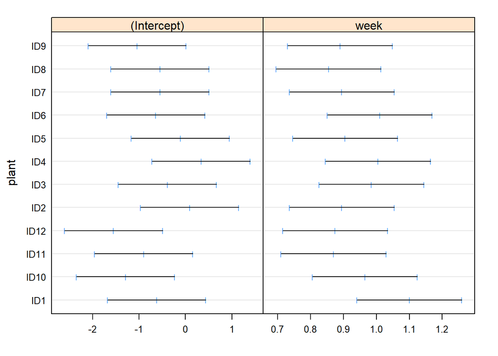

```r
plot(nlme::intervals(lm2.list))
```

In this plot it is possible to see that the plants have not really different slopes. So it does not make really sense to fit a random slope. For the plants we have to fit random intercept because of the grouping. There is considerable overlap in the set of intervals for the slope with respect to week. It may be feasible to use a model with a common slope. The non difference in intercepts is because we are comparing intercepts at week 0, data that we do not have and where we do not expect any difference of the treatment (because the tr+itment hadn´t started). Let´s correct this: LEt´s not compare intercepts at week 0 but at the end or middle of the experiment.

```r
lm2.list<- lmList( root ~ I(week-8)|plant, data = fertilizer )
lm2.list
```

```
## Call:
##   Model: root ~ I(week - 8) | plant
##    Data: fertilizer
##
## Coefficients:
##      (Intercept) I(week - 8)
## ID1        8.180       1.100
## ID10       6.430       0.965
## ID11       6.060       0.870
## ID12       5.450       0.875
## ID2        7.250       0.895
## ID3        7.490       0.985
## ID4        8.376       1.005
## ID5        7.130       0.905
## ID6        7.440       1.010
## ID7        6.610       0.895
## ID8        6.290       0.855
## ID9        6.080       0.890
##
## Degrees of freedom: 60 total; 36 residual
## Residual standard error: 0.4966309
```

```r
intervals(lm2.list)
```

```
## , , (Intercept)
##
##         lower  est.    upper
## ID1  7.628326 8.180 8.731674
## ID10 5.878326 6.430 6.981674
## ID11 5.508326 6.060 6.611674
## ID12 4.898326 5.450 6.001674
## ID2  6.698326 7.250 7.801674
## ID3  6.938326 7.490 8.041674
## ID4  7.824326 8.376 8.927674
## ID5  6.578326 7.130 7.681674
## ID6  6.888326 7.440 7.991674
## ID7  6.058326 6.610 7.161674
## ID8  5.738326 6.290 6.841674
## ID9  5.528326 6.080 6.631674
##
## , , I(week - 8)
##
##          lower  est.    upper
## ID1  0.9407455 1.100 1.259255
## ID10 0.8057455 0.965 1.124255
## ID11 0.7107455 0.870 1.029255
## ID12 0.7157455 0.875 1.034255
## ID2  0.7357455 0.895 1.054255
## ID3  0.8257455 0.985 1.144255
## ID4  0.8457455 1.005 1.164255
## ID5  0.7457455 0.905 1.064255
## ID6  0.8507455 1.010 1.169255
## ID7  0.7357455 0.895 1.054255
## ID8  0.6957455 0.855 1.014255
## ID9  0.7307455 0.890 1.049255
```

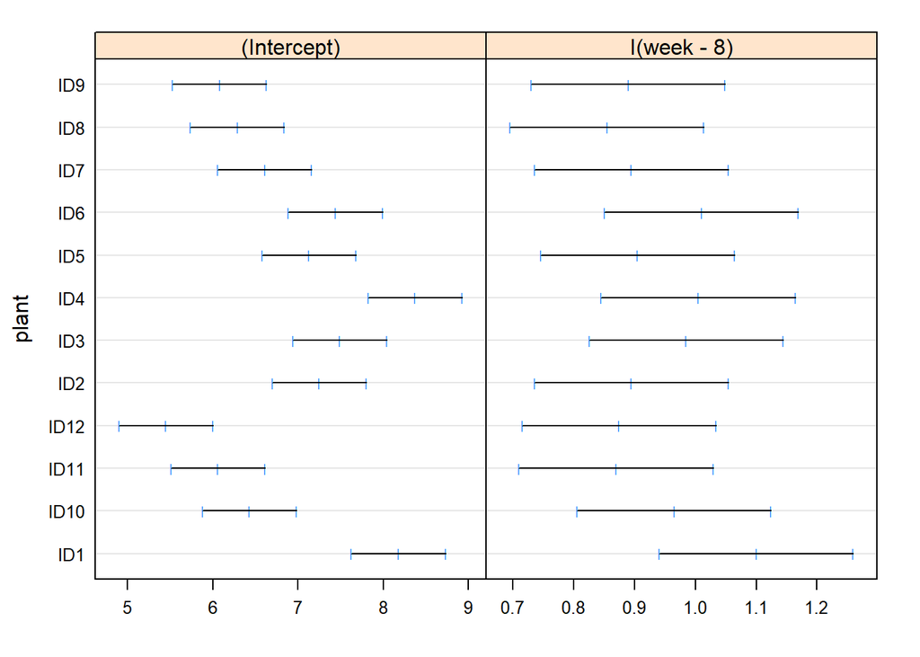

```r
plot(intervals(lm2.list))
```

### Fit the model using `lme4`

```r
lmer.1 <- lmer(root ~ week*fertilizer + (1|plant) + (0+week|plant), data=fertilizer)

#Equivalent syntax:
 #lmer.1 <- lmer(root~week*fertilizer + (week||plant), data=fertilizer)
 #lmer.1 <- lmer(root~week*fertilizer+ 1 + (1|plant) + (0+week|plant))
```

We check the summary

```r
summary(lmer.1)
```

```
## Linear mixed model fit by REML ['lmerMod']
## Formula: root ~ week * fertilizer + (1 | plant) + (0 + week | plant)
##    Data: fertilizer
##
## REML criterion at convergence: 105
##
## Scaled residuals:
##     Min      1Q  Median      3Q     Max
## -1.6953 -0.6984 -0.1626  0.6948  2.2986
##
## Random effects:
##  Groups   Name        Variance Std.Dev.
##  plant    (Intercept) 0.054568 0.23360
##  plant.1  week        0.001283 0.03582
##  Residual             0.218528 0.46747
## Number of obs: 60, groups:  plant, 12
##
## Fixed effects:
##                        Estimate Std. Error t value
## (Intercept)            -0.22233    0.22172  -1.003
## week                    0.98333    0.03353  29.325
## fertilizercontrol      -0.75767    0.31355  -2.416
## week:fertilizercontrol -0.09167    0.04742  -1.933
##
## Correlation of Fixed Effects:
##             (Intr) week   frtlzr
## week        -0.735
## frtlzrcntrl -0.707  0.520
## wk:frtlzrcn  0.520 -0.707 -0.735
```

**Scaled residuals** We see there is a simmetrical distribution. A very non simetrical disrtibution could be a problem.

**Random effects** Again random slope does not explain much variance. Also Plant ID does not have a big variance, is smaller than the residuals. Plants are not very different to each other. We can remove the random slope. Not the random intercept because we have to account for the correlation of all the meassurements done in the same plant.

**Fixed effects** We do not know if they are significant or not. But we can compare the effect with the std. error to see if it is important. Week has an effect one order of magnitude bigger than its standard error. That means something! Fertilizer and the interaction effects are only twice the Std. Error. This means that the effect is not much bigger than the error. I wouls try to fit the model without the itneraction.

**Correlation of fixed effects** Correlation between the parameters. Is high, that is fine. It just does not have to be one which would mean no convergence of the model fitting.

I would first take out the random slopes, compare. Then take out the interaction, and then compare

```r
lmer.2 <- lmer(root ~ week * fertilizer + (1|plant), REML = TRUE, data= fertilizer)
anova (lmer.1, lmer.2)
```

```
## Data: fertilizer
## Models:
## lmer.2: root ~ week * fertilizer + (1 | plant)
## lmer.1: root ~ week * fertilizer + (1 | plant) + (0 + week | plant)
##        Df    AIC    BIC  logLik deviance  Chisq Chi Df Pr(>Chisq)
## lmer.2  6 103.29 115.86 -45.646   91.293
## lmer.1  7 104.90 119.56 -45.451   90.902 0.3911      1     0.5317
```

So we can discard the random slope. This is not magic, it is usually what you see in the plots of your data.

now lets discar the interaction. We are modifying the fixed effects, so we need ML to compare.

```r
update(lmer.2, REML = FALSE)
```

```
## Linear mixed model fit by maximum likelihood  ['lmerMod']
## Formula: root ~ week * fertilizer + (1 | plant)
##    Data: fertilizer
##      AIC      BIC   logLik deviance df.resid
## 103.2927 115.8588 -45.6464  91.2927       54
## Random effects:
##  Groups   Name        Std.Dev.
##  plant    (Intercept) 0.2937
##  Residual             0.4639
## Number of obs: 60, groups:  plant, 12
## Fixed Effects:
##            (Intercept)                    week       fertilizercontrol
##               -0.22233                 0.98333                -0.75767
## week:fertilizercontrol
##               -0.09167
```

```r
lmer.3 <- lmer ( root ~ week + fertilizer + (1|plant), RMEL = FALSE, data= fertilizer)
anova(lmer.2, lmer.3)
```

```
## Data: fertilizer
## Models:
## lmer.3: root ~ week + fertilizer + (1 | plant)
## lmer.2: root ~ week * fertilizer + (1 | plant)
##        Df    AIC    BIC  logLik deviance  Chisq Chi Df Pr(>Chisq)
## lmer.3  5 105.76 116.24 -47.882   95.764
## lmer.2  6 103.29 115.86 -45.646   91.293 4.4715      1    0.03446 *
## ---
## Signif. codes:  0 '***' 0.001 '**' 0.01 '*' 0.05 '.' 0.1 ' ' 1
```

The model with the interaction is better. So we finally keep it.

# Exercise 3

Use the above specified models and refit them with Maximum Likelihood

- nlme: specify `method = "ML"`
- lme4: specify `REML = FALSE`

in both packages REML is the default!). How do the variance and covariance values change with Maximum Likelihood

REML variance is larger because it accounts for the fact that the fixed parameters are estimated.

Residuals might be the same, because what changes is the variance of te “random” effects.

```r
lmer.REML <- lme(root ~ week * fertilizer, random = ~ 1|plant, data = fertilizer, method = "REML")

lmer.ML <- lme(root ~ week * fertilizer, random = ~ 1|plant, data = fertilizer, method = "ML")


VarCorr(lmer.REML)
```

```
## plant = pdLogChol(1)
##             Variance  StdDev
## (Intercept) 0.1102545 0.3320459
## Residual    0.2245166 0.4738319
```

```r
VarCorr(lmer.ML)
```

```
## plant = pdLogChol(1)
##             Variance   StdDev
## (Intercept) 0.08626525 0.2937095
## Residual    0.21516194 0.4638555
```

Estimated variances are lower for ML because in the calculation it does not account for the uncertainty of the parameters.

# Exercise 4

For each of the models, calculate the intraclass correlations. LEtÂ´s first remember what was the inetr class correlation (ICC)

$ICC = \frac{Varriance_{btw groups}}{Variance_{btw groups}+Variance_{within group}}$

```r
model.2 <- lme(size~N, data=farms, random = ~ 1|farm )
model.4 <- lmer (size~N+(1|farm), data = farms)
model.7 <- lmer(root~week*fertilizer + (week||plant), data=fertilizer)
```

Model 2

```r
VarCorr(model.2)
```

```
## farm = pdLogChol(1)
##             Variance  StdDev
## (Intercept) 72.354531 8.506147
## Residual     3.724354 1.929859
```

We do the calculation

```r
72.354531 / (72.354531 + 3.724354)
```

```
## [1] 0.9510462
```

Model 3

```r
VarCorr(model.4)
```

```
##  Groups   Name        Std.Dev.
##  farm     (Intercept) 8.5061
##  Residual             1.9299
```

We only get back the std. Dev. So we have to square this number.

```r
8.5061^2/(8.5061^2+  1.9299 ^2)
```

```
## [1] 0.9510436
```

Model 4

```r
VarCorr(model.7)
```

```
##  Groups   Name        Std.Dev.
##  plant    (Intercept) 0.233598
##  plant.1  week        0.035821
##  Residual             0.467469
```

```r
0.233598^2 / (0.233598^2 + 0.035821^2 + 0.467469^2)
```

```
## [1] 0.1988787
```

# Exercise 5

Load the data set “rats”. Glycogen concentrations was measured under 3 treatments, applied to 6 rats (replication of 2). From each rat three pieces of its liver were taken, and two preperations per liver piece were made.

### Investigate the data

```r
rats <- read.delim("data/rats.txt")
head(rats)
```

```
##   Glycogen Treatment Rat Liver
## 1      131         1   1     1
## 2      130         1   1     1
## 3      131         1   1     2
## 4      125         1   1     2
## 5      136         1   1     3
## 6      142         1   1     3
```

```r
xtabs(~ Treatment + Rat + Liver, data = rats )
```

```
## , , Liver = 1
##
##          Rat
## Treatment 1 2
##         1 2 2
##         2 2 2
##         3 2 2
##
## , , Liver = 2
##
##          Rat
## Treatment 1 2
##         1 2 2
##         2 2 2
##         3 2 2
##
## , , Liver = 3
##
##          Rat
## Treatment 1 2
##         1 2 2
##         2 2 2
##         3 2 2
```

```r
str(rats)
```

```
## 'data.frame':    36 obs. of  4 variables:
##  $ Glycogen : int  131 130 131 125 136 142 150 148 140 143 ...
##  $ Treatment: int  1 1 1 1 1 1 1 1 1 1 ...
##  $ Rat      : int  1 1 1 1 1 1 2 2 2 2 ...
##  $ Liver    : int  1 1 2 2 3 3 1 1 2 2 ...
```

```r
rats$Treatment <- factor(rats$Treatment)
rats$Rat <- factor(rats$Rat)
rats$Liver <- factor(rats$Liver)
```

Some plots to see how the data looks like:

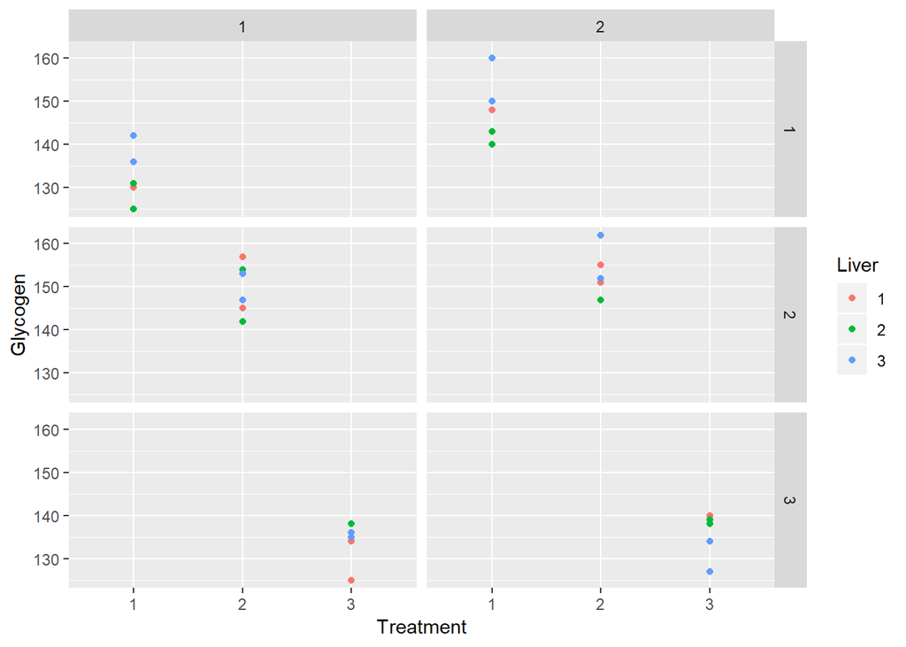

```r
rats %>% ggplot( aes(y=Glycogen, x=Treatment, group=Liver, color=Liver))+
  geom_point()+
  facet_grid(Treatment~Rat)
```

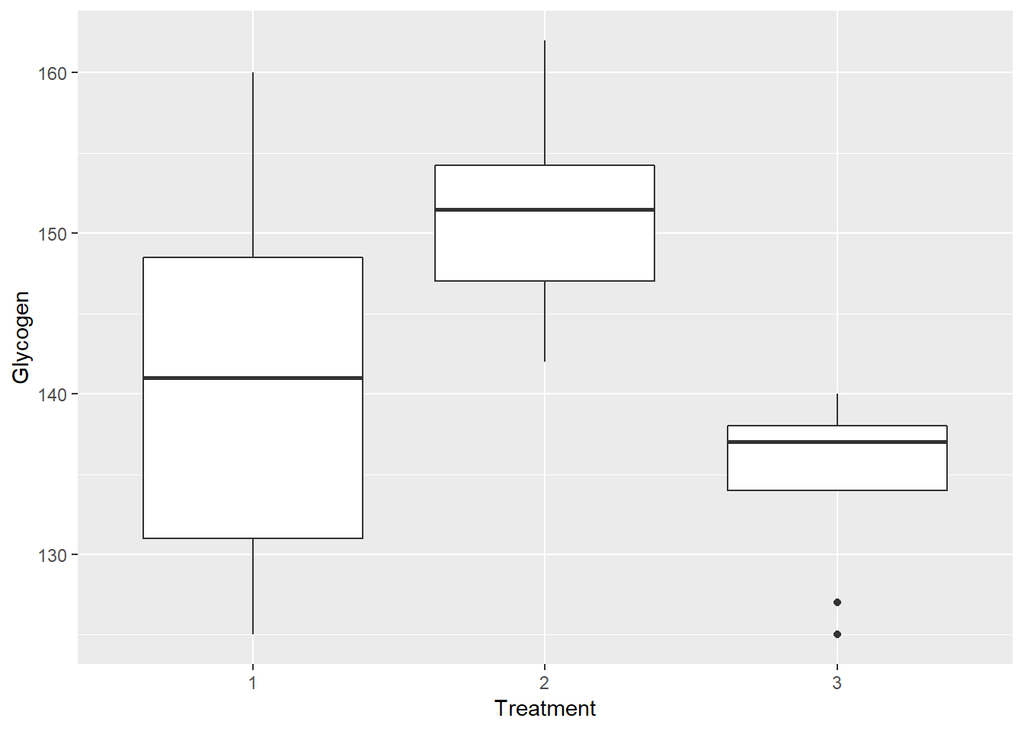

```r
rats %>% ggplot(aes(y=Glycogen, x=Treatment))+
                   geom_boxplot()
```

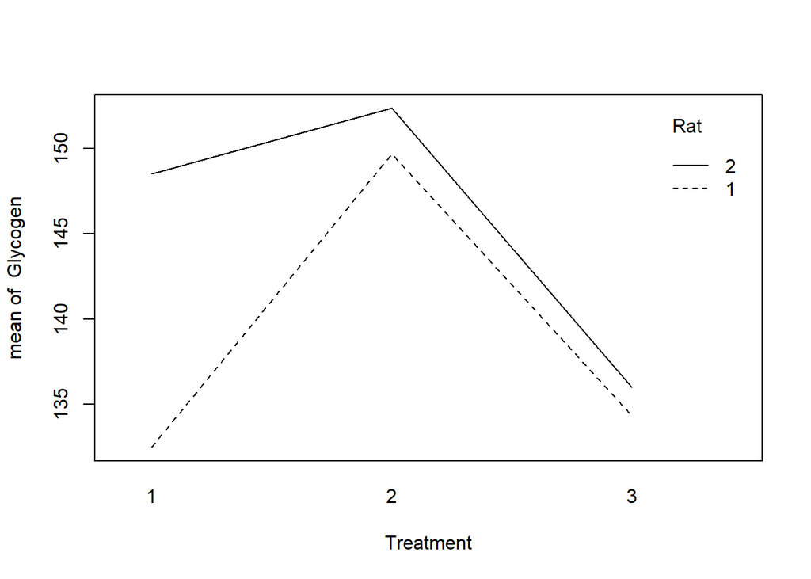

```r
 with(rats, (interaction.plot(Treatment, Rat, Glycogen)))
```

The exercise does not tell, but of course the same rat can not recieve more than one treatment. There is two rats per treatment. And for each rat there are three measurements because the liver was cuttet in three bits (of course pseudoreplication)

### Answer the recipie questions

- Follow the above recipe: where is the grouping, how many random effects, nested or crossed? Fixed effects? Random slopes?

The recipe for implementing a Mixed Effects Model is

1. spot the grouping in the data

There is groupping inside each rat.

2. how many random effects are there in the data?

Rat and liver are RE

3. if two or more, are they nested? Can you spot that from the data labeling, or if not, is there any reason to suspect nesting / crossing?

They are nested, each liver bellongs to one rat

4. define the deterministic part of the model, i.e. find the fixed effects incl. their interactions and potential quadratic / cubic etc. terms

We are intreated in the effect of treatment on glycogen

5. can you specify random slopes for one or all of the ranodm effects?

In this case there is no continious predictor so no random effect.

### Fit with lmer

```r
model<-lmer(Glycogen~Treatment+(1|Treatment/Rat/Liver), data=rats)
summary(model)
```

```
## Linear mixed model fit by REML ['lmerMod']
## Formula: Glycogen ~ Treatment + (1 | Treatment/Rat/Liver)
##    Data: rats
##
## REML criterion at convergence: 219.6
##
## Scaled residuals:
##      Min       1Q   Median       3Q      Max
## -1.48212 -0.47263  0.03062  0.42934  1.82935
##
## Random effects:
##  Groups                Name        Variance Std.Dev.
##  Liver:(Rat:Treatment) (Intercept) 14.17    3.764
##  Rat:Treatment         (Intercept) 36.06    6.005
##  Treatment             (Intercept) 26.74    5.171
##  Residual                          21.17    4.601
## Number of obs: 36, groups:
## Liver:(Rat:Treatment), 18; Rat:Treatment, 6; Treatment, 3
##
## Fixed effects:
##             Estimate Std. Error t value
## (Intercept)  140.500      6.993  20.092
## Treatment2    10.500      9.889   1.062
## Treatment3    -5.333      9.889  -0.539
##
## Correlation of Fixed Effects:
##            (Intr) Trtmn2
## Treatment2 -0.707
## Treatment3 -0.707  0.500
```

Or, in roder not to specify tratment as random we change names of rats to give unique names to each real rat an liver bit

```r
rats$Rat2 <- paste0("T",rats$Treatment, "R",rats$Rat)
rats$Liver2 <- paste0("T", rats$Treatment, "R", rats$Rat, "L", rats$Liver)

model2 <- lmer(Glycogen~Treatment+(1|Rat2/Liver2), data=rats)
summary(model2)
```

```
## Linear mixed model fit by REML ['lmerMod']
## Formula: Glycogen ~ Treatment + (1 | Rat2/Liver2)
##    Data: rats
##
## REML criterion at convergence: 219.6
##
## Scaled residuals:
##      Min       1Q   Median       3Q      Max
## -1.48212 -0.47263  0.03062  0.42934  1.82935
##
## Random effects:
##  Groups      Name        Variance Std.Dev.
##  Liver2:Rat2 (Intercept) 14.17    3.764
##  Rat2        (Intercept) 36.06    6.005
##  Residual                21.17    4.601
## Number of obs: 36, groups:  Liver2:Rat2, 18; Rat2, 6
##
## Fixed effects:
##             Estimate Std. Error t value
## (Intercept)  140.500      4.707  29.848
## Treatment2    10.500      6.657   1.577
## Treatment3    -5.333      6.657  -0.801
##
## Correlation of Fixed Effects:
##            (Intr) Trtmn2
## Treatment2 -0.707
## Treatment3 -0.707  0.500
```

Whether you explicitly specify a random effect as nested or not depends (in part) on the way the levels of the random effects are coded. If the ‘lower-level’ random effect is coded with unique levels, then the two syntaxes (1|a/b) (or (1|a)+(1|a:b)) and (1|a)+(1|b) are equivalent. If the lower-level random effect has the same labels within each larger group (e.g. blocks 1, 2, 3, 4 within sites A, B, and C) then the explicit nesting (1|a/b) is required. It seems to be considered best practice to code the nested level uniquely (e.g. A1, A2, ., B1, B2, .) so that confusion between nested and crossed effects is less likely.

+++++++++++++++++++++++++++++++++++++++++++++++++++++++++

Answer to the exercises Mixed Effects Models With R Professor: Arne SchrÃ¶der Tutor: Elisa Schneider Intended for the only purpose of teaching @ Freiburg University Sources: Mick Crawley, R book, 2nd edition; Zuur, Ieno, Walker, Saveliev and Smith 2009 Mixed Effects Models and Extensions in Ecology with R; Pinheiro and Bates 2000. Mixed effects models in S and S-plus.

++++++++++++++++++++++++++++++++++++++++++++++++++++++++++